# Writing Custom Aggregation Functions

Mazama Science

5/1/2020

### Temporal Aggregation

An essential piece of analysis of large data is efficient granularization: computing aggregations like `sum`, `mean`, `sd`, `min`, and `max`, in which a single number gives insight into the nature of a potentially large dataset. *Time series* aggregation is the aggregation of all data points over a specified *period*. In the **AirSensor** context, this is achieved via `pat_aggregate()`, using a function similar to those mentioned above, over a (default) 1-hour period. The result of the aggregation is one data point that reflects a statistical view of the collected and aggregated data points over the hour.

To demonstrate this feature we’ll load a 24-hour period of sensor and compare the data to the aggregated data.

```r
# AirSensor setup
library(AirSensor)
setArchiveBaseUrl("https://airfire-data-exports.s3-us-west-2.amazonaws.com/PurpleAir/v1")

# Load the PurpleAir sensor data
pas <- pas_load()
pat <- pat_load(label = 'SCSC_33', pas = pas) %>% pat_filterDate(20200501, 20200502)
```

A standard 24-hour period of non-aggregated data typically consists of 720 data entries, an entry every 2 minutes.

```r
nrow(pat$data)
```

```
## [1] 720
```

Here is a multi-plot of how the non-aggregated data looks.

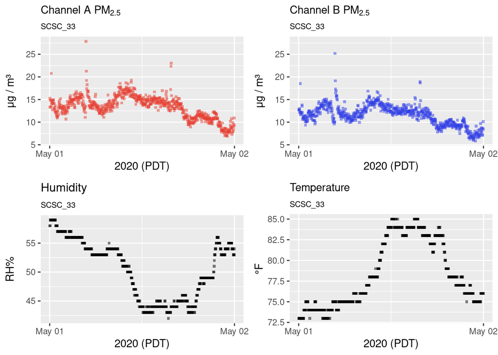

```r
p1 <- pat_multiplot(pat, sampleSize = NULL)
p1
```

#### 1-hour Aggregation

Using `pat_aggregate()` we can aggregate the `pat` object to an hourly average of the data.

```r
hourly_pat <- pat_aggregate(pat, mean, na.rm = TRUE)
nrow(hourly_pat$data)
```

```
## [1] 24
```

As we’d expect, an hourly aggregated `pat` contains 24 entries, an entry every hour.

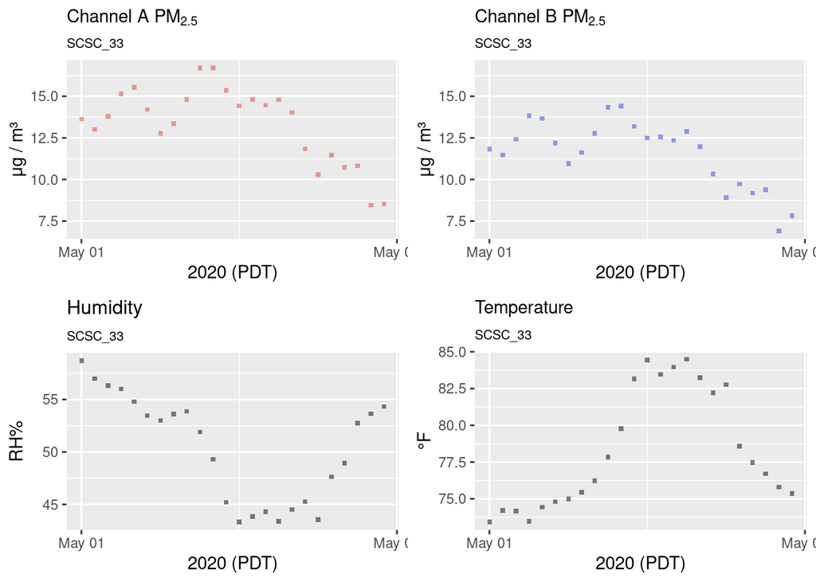

```r
p2 <- pat_multiplot(hourly_pat)
p2
```

#### Advanced Aggregation Methods

In order to write custom aggregation functions for use with `pat_aggregate()`, we must first familiarize ourselves with `pat_aggregate()`’s underlying algorithm. When executed, `pat_aggregate(pat, FUN)` utilizes the `datetime` axis of a PurpleAir time series object (`pat`) to split the data into time-granular bins. Each bin has the supplied function `FUN` mapped to the numeric vectors within the `pat` data. `FUN` is capable of accepting *any* valid R function, and as with any great power comes great responsibility. The only requirements for the function are `FUN` *must* operate on univariate numeric data and return a scalar value (think`sum`, or `mean`). The last step in `pat_aggregate()` is to combine the transformed bins along a shortened `datetime` axis and return a data object of the same `pat` class (`pa_timeseries`).

With care, we can extend the use of `pat_aggregate()` to summarize time series `pat` data of nearly *any* period. You can create different aggregation periods by explicitly providing `f`, string describing the period to split by `f =` `'hours'`, `'minutes'`, `'weeks'`, `'months'`, etc. and `k`, a number of periods to aggregate in each bin. For example, a 15-minute standard deviation (`sd`) aggregation would look as follows:

```r
# Aggregate the standard deviation of 15-minute periods
sd_fifteen_minute_pat <- pat_aggregate(pat, sd, na.rm = TRUE, f = 'minutes', k = 15)

# View first 5 entries of data
head(sd_fifteen_minute_pat$data)
```

```
##              datetime    pm25_A    pm25_B pm1_atm_A pm1_atm_B pm25_atm_A
## 1 2020-05-01 07:01:00 2.6146055 2.2719218 1.2776336 1.1381397  2.6146055
## 2 2020-05-01 07:15:00 0.7265968 0.8182211 0.4885821 0.7068643  0.7265968
## 3 2020-05-01 07:31:00 0.7212423 0.2699647 0.6789418 0.3083520  0.7212423
## 4 2020-05-01 07:45:00 0.8158738 0.7022095 0.6548446 0.4982953  0.8158738
## 5 2020-05-01 08:01:00 1.1708503 0.6680177 0.5938414 0.4471018  1.1708503
## 6 2020-05-01 08:15:00 0.7452660 0.5206160 0.4763533 0.3558792  0.7452660
##   pm25_atm_B pm10_atm_A pm10_atm_B pm25_cf1_A pm25_cf1_B temperature  humidity
## 1  2.2719218  2.8668964  2.5051708  2.3255639  2.1259384   0.0000000 0.4879500
## 2  0.8182211  0.9548738  0.9619762  0.7265968  0.8182211   0.0000000 0.0000000
## 3  0.2699647  0.6384058  0.4873544  0.7212423  0.2699647   0.4879500 0.0000000
## 4  0.7022095  0.7314565  1.0610372  0.8158738  0.7022095   0.5175492 0.3535534
## 5  0.6680177  0.9619895  0.8819945  1.1708503  0.6680177   0.0000000 0.0000000
## 6  0.5206160  0.8602616  0.6436670  0.7452660  0.5206160   0.3535534 0.0000000
##     uptime adc0      rssi          datetime_A          datetime_B
## 1 4.320494    0 0.7867958 2020-05-01 07:01:00 2020-05-01 07:01:00
## 2 4.898979    0 0.9161254 2020-05-01 07:15:00 2020-05-01 07:15:00
## 3 4.320494    0 1.3972763 2020-05-01 07:31:00 2020-05-01 07:31:00
## 4 4.898979    0 1.1952286 2020-05-01 07:45:00 2020-05-01 07:45:00
## 5 4.320494    0 1.3801311 2020-05-01 08:01:00 2020-05-01 08:01:00
## 6 4.898979    0 2.2320714 2020-05-01 08:15:00 2020-05-01 08:15:00
```

Aggregation by different periods is an important concept to recognize for advanced usage because it can be utilized in a number of ways, such as writing robust quality-control algorithms or speeding up calculations.